# PR9 - Package

강현승

2022-11-03

# 1. package 기본

> 해당 실습에서 자주 나오는 패키지 설치를 반복하면 문서 생성 시 에러가 나기 때문에, 설치가 되었다면 주석 처리 해주시고 Rmd에서는 패키지를 불러오는 코드만 포함시키시면 됩니다. 추가로 패키지 설치는 Rmd보다는 Script에서 진행해주시는게 좋습니다.
- R에서 기본적으로 제공하는 함수 외에 다른 프로그래머들이 필요하다고 생각해서 만들어 놓은 함수들의 모음
- 이것을 보통 library 또는 API라고 칭함
- R에서는 보통 CRAN에서 R재단이 인정한 패키지들을 공유
- 비공식적이지만 개인이 만들어서 공유하는 패키지들이 있는데 보통 github에 업로드되어 있음

## 1.1. 설치

- 설치 명령어: `install.packages()`
- 다음 시간 사용할 크롤링 관련 페키지 설치

```r
# install.packages("ryest")
# install.packages("httr")
# install.packages("RSelenium")
```

## 1.2. 불러오기

- 패키지를 불러오는 방법은 크게 두 가지가 있습니다.
  - library(package이름): 설치되어 있는 패키지를 불러옴
  - require(package이름): 불러오려는 시도를 하고 logical한 return 값을 반환
- `require()`도 결과적으로 `library()`와 동일한 기능을 하지만, 결과 값에서 차이가 나게 됩니다.
  - `library()`는 패키지를 불러오는 것으로, 패키지가 없다면 에러 메세지를 반환할 것입니다.
  - 하지만 `require()`는 패키지가 없다고 해서 에러메세지를 반환하는 것이 아닌, 패키지 유무에 대한 논리 값을 반환할 것입니다.

```r
x = library(rvest)
x
```

```
## [1] "rvest"     "stats"     "graphics"  "grDevices" "utils"     "datasets"
## [7] "methods"   "base"
```

```r
x = require(rvest)
x
```

```
## [1] TRUE
```

```r
# 해당 패키지가 없다고 에러가 뜨면서 결과 knit 시 에러가 발생할 수 있는 부분입니다.
# library(chron)

# 해당 패키지가 없어서 에로가 뜨지 않고 knit를 정상적으로 할 수 있습니다.
require(chron)
```

## 1.3. 패키지 업데이트

- 패키지 개발자가 자신이 만든 패키지의 기능을 보안하거나 R 버전이 업데이트 되어 호환이 되도록 수정하거나 오류를 수정
- 명령어는 `update.packages(패키지 이름)`
- RStudio를 사용하는 경우 우측 하단의 packages 탭의 update 항목을 통해 원하는 패키지 혹은 전체 패키지의 업데이트 가능

```r
# update.packages('rvest)
```

## 1.4. 불러온 패키지 사용 중지

```r
# detach('package:ggplot2', unload = T)
```

# 2. package 고급

## 2.1. package에서 함수 가져오기

- 다양한 패키지들을 불러오다 보면, 동일한 함수명을 사용해서 서로 충돌할 때가 있습니다.
- 그럴 때는 `패키지명::함수명`으로 어떤 패키지에서 해당 함수를 사용할 것인지 명시해서 문제를 해결할 수 있습니다.

```r
# require(plyr)
# require(Hmisc)
# require(chron)
# require(tseries)
#
# plyr::summarize()
# Hmisc:summarize()
#
# chron::is.weekend()
# tseries::is.weekend()
```

- **실습**: 본인이 최근 사용해 본 패키지에서 해당 사용법으로 패키지 함수를 하나 사용해보시기 바랍니다.

```r
# install.packages('rjson')
# install.packages('jsonlite')
# install.packages('httr')

library(httr)
library(rjson)
library(jsonlite)
url = 'https://jsonplaceholder.typicode.com/comments'

by_rjson = rjson::fromJSON(json_str = content(GET(url), as = 'text'))
by_jsonlite = jsonlite::fromJSON(url)
```

## 2.2. 패키지 삭제

- 패키지의 재설치가 필요하거나, 더 이상 쓸모가 없어진 패키지들을 삭제해야 할 필요가 있을때, `remove.packages()`를 사용합니다.

```r
# remove.packages("rvest")
```

## 2.3. 편리한 사용자 정의 함수

- 해당 함수는 패키지명으로 구성된 문자형 벡터를 입력으로 받아서, 설치 및 불러오기를 동시에 진행하는 함수입니다.
- 만약 해당 패키지가 이미 설치되어 있는 패키지라면 바로 설치과정을 생략하고 바로 불러오기를 진행하게 됩니다.

```r
take = function(x) {
  for (i in x) {
    if (!is.element(i, .packages(all.available = TRUE))) {
      install.packages(i)
    }
    library(i, character.only = TRUE)
  }
}

take(c("rvest", "httr"))
```

# 3. `devtools`

- `devtools`의 주목적은 패키지 개발에 필요한 많은 작업들을 단순화시키는 것인데, 뿐만 아니라 비공식패키지의 설치와 패키지 버전 관리 측면에서도 상당히 중요한 패키지입니다.

## 3.1. 비공식 패키지 설치

- CRAN에서 제공하는 패키지가 아닌, github에 공개되어 있는 다양한 패키지들도 설치하여 사용할 수 있습니다.

```r
# install.packages("devtools")
library(devtools)
# install_github("패키지")
```

## 3.2. 원하는 버전 설치

- R의 패키지들이 최신 버전에 맞춰서 업데이트가 되지 않았다면, 이전 버전의 패키지를 사용해야만 할 경우들이 있으며 이때 사용하는 것이 `devtools`의 `install_version()`입니다.
- install_version(“패키지명”, version=“버전명”, repos=“http://cran.us.r-project.org”)
  - 패키지명과 어떤 버전명을 지정해주면 되며, **repos**는 어떤 서버에서 해당 내용을 다운받을지 지정해주는 것입니다.
- 예시로 `ggplot2`를 들어보겠습니다. 2020년 05월 12일 기준 3.3.0이 최신버전인데, 0.9.1 버전을 설치해보는 것으로 하겠습니다.
- 이미 `ggplot2`가 설치되어 있으신 분들은 앞에서 배운 패키지 삭제를 통해 삭제하고 진행해주십시오.

```r
# library(devtools)

# remove.packages("ggplot2")
# install_version("ggplot2", version = "0.9.1", repos = "http://cran.us.r-project.org")
# packageVersion("ggplot2") # 설치된 패키지 버전 체크
```

- 이 과정을 실습해보셨다면 `ggplot2`를 지워주시고, 밑의 `tidyverse`로 설치를 진행해주시면 됩니다.

```r
# remove.packages("ggplot2")
```

# 4.`tidyverse`

`tidyverse`는`dplyr`, `tidyr`, `ggplot2` 등, R 프로그래밍의 핵심패키지들을 한번에 설치 및 관리해주는 패키지입니다.

```r
# install.packages("tidverse")
# install.packages("glue")
library(tidyverse)
```

# PR9 연습문제

```r
# install.packages('devtools')
# install.packages('roxygen2')
# library(devtools)
# library(roxygen2)
#
# setwd('create-r-package-practice/')
# getwd()
# package.skeleton(name = 'addnumbers',
#                  code_files = c('add_fun.R'))
# roxygenize('addnumbers')
```

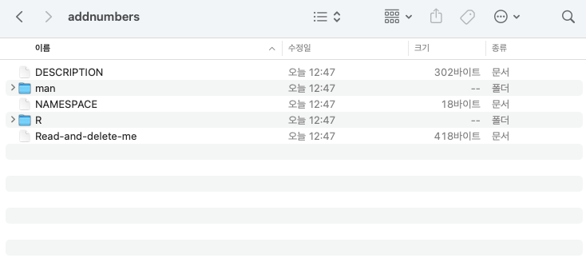

## PR9 연습 결과

깃헙 리포에 패키지 올려서 설치 후 결과 https://github.com/khskeb0513/create-r-package-practice

```r
# devtools::install_github('khskeb0513/create-r-package-practice')
addnumbers::add_fun(1, 2, 3, 4, 5)
```

```
## [1] 15
```